# A Little Covid-19 Research

Noam Malki

8.9.2021

### Introduction:

The COVID-19 pandemic didn’t disappear from our life.  
It still affects our mundane life.

The first outbreak of COVID-19 started in Wuhan, China in November 2019.  
The World Health Organization declared the COVID-19 outbreak a pandemic on 11 March 2020.  
More than a year and a half afterwards, the pandemic is still here.  
So it’s very important to study it. This is what I’m going to do here.

First of all, I will examine the current state of Coronavirus’ confrimed cases, deaths and their relation around the world.  
Secondly, I will examine the correlation between the Coronavirus death rate and some demographic variables.  
Finally, I will build a prediction model of the Coronavirus death rate and examine its accuracy.

I’ll use data from the World Health Organization (WHO), UN and gapminder websites.  
Let’s begin.

### Confirmed cases, deaths and its relation:

The following plot shows the numbers of COVID-19 confrimed cases per million around the world.

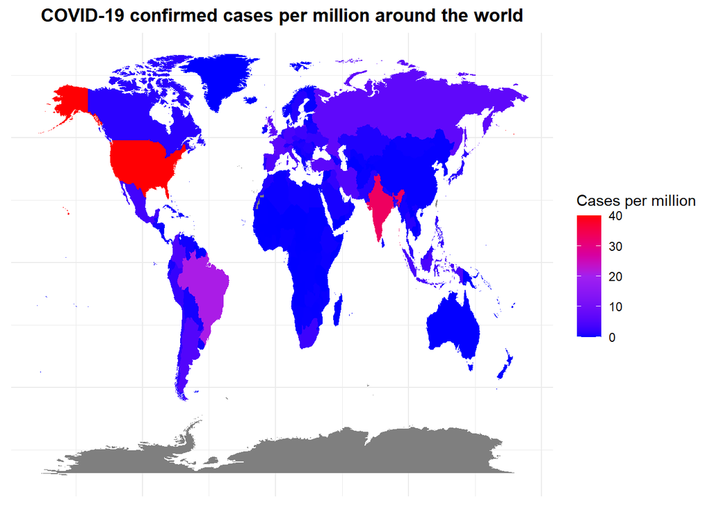

As you can see USA, India and Brazil has the most counfirmed cases around the world.

The next plot shows the numbers of COVID-19 deaths per 100 thounsands around the world.

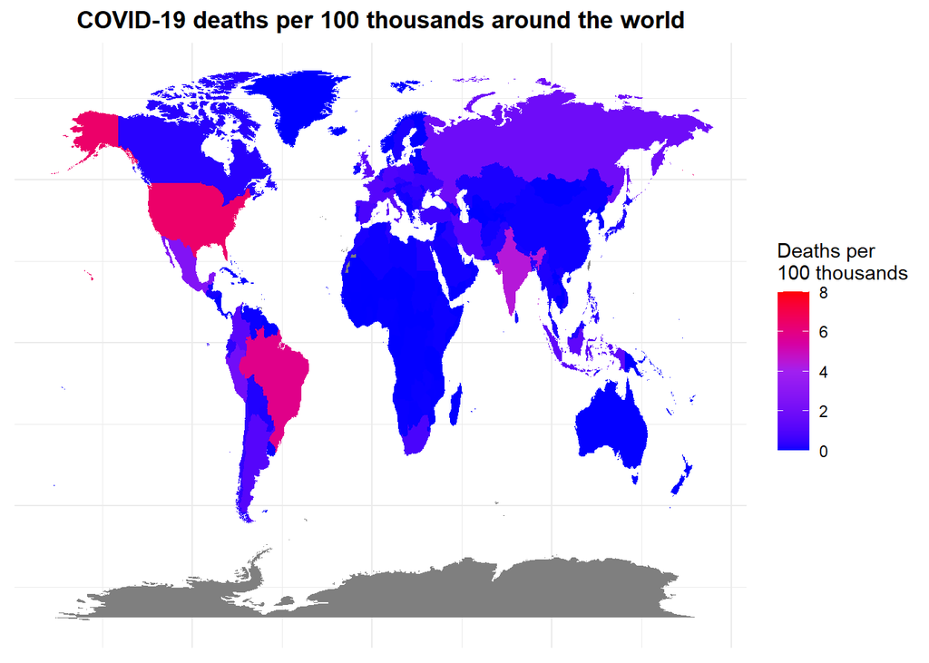

As you can see USA, India and Brazil also have the most deaths around the world.

Denote the Coronavirus death rate as:
$$\frac{\mathsf{Deaths}}{\mathsf{Cases}}$$

when `Cases` are the total confirmed cases and `Deaths` are the total deaths.  
Considering the plots above, we can assume that the Brazil, India and USA will some from the worst rates.

The following plot will check our assumption.

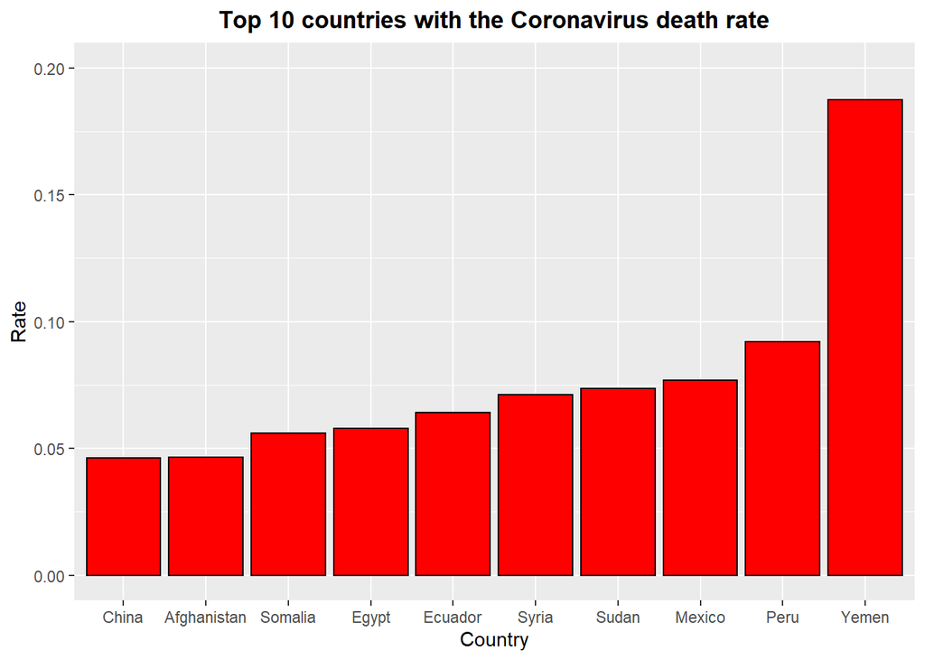

As you see, our hypothesis was wrong: the 3 afromentioned countries didn’t make it to the top 10.  
How can it be? maybe there are some variables that affect the rate. The next part will examine the correlation between demographic data and the rate.

### Demographic data:

I chose to focus on the demographic variables: population density, life expectancy and income in dollars. High life expectancy can affect the rate because the coronavirus disease affect more the elderly. High population density can affect the rate because there is higher possibility to get infected in dense areas. Low income can influence the rate because maybe the sanitation is bad in low-income areas. Some of the countries don’t have al least one of this variables so I dropped them (in the end, we have 179 observations in the dataset).

The following table shows the correlations between the afromentioned variables, the total cases and the rate.

|  | Rate | Total_cases | PopDensity | Income | Expectancy |
| --- | --- | --- | --- | --- | --- |
| Rate | 1.000 | 0.002 | -0.133 | -0.239 | -0.120 |
| Total_cases | 0.002 | 1.000 | -0.018 | 0.130 | 0.130 |
| PopDensity | -0.133 | -0.018 | 1.000 | 0.284 | 0.203 |
| Income | -0.239 | 0.130 | 0.284 | 1.000 | 0.681 |
| Expectancy | -0.120 | 0.130 | 0.203 | 0.681 | 1.000 |

As you can see, there are low correlations between the rate and variables above.  
Only the cases have positive correlation with the rate (that’s weird), but the low income influences the rate as we suspeced.

### Prediction model:

Firstly I split the data to a training set, which contains 70% of the data, and test set the contains the remained 30%.

The following table compare the train and test errors with two different measures (RMSE and MAE).

|  | Train | Test |
| --- | --- | --- |
| RMSE | 0.011 | 0.013 |
| MAE | 0.006 | 0.010 |

All the error are low, so we succeeded to predict the rate. But the low number of variables and observations might affect our predictions. Future researches should consider more variables and find more reliable demographic datasets.

### Refrence list:

1. [Timeline of the COVID-19 pandemic, Wikipedia](https://en.wikipedia.org/wiki/Timeline_of_the_COVID-19_pandemic)
2. [UN website](https://population.un.org/wpp/Download/Standard/CSV/)
3. [Gapminder website](https://www.gapminder.org/data/)
4. [WHO website, Wikipedia](https://covid19.who.int/)